# Storm Kristin, Portugal, January 2026

Storm Kristin made landfall on the Iberian Peninsula in late January 2026, bringing significant precipitation to Portugal and Spain. This report summarizes station-level precipitation and temperature data from NOAA’s [Global Historical Climatology Network – Daily (GHCN-D)](https://www.ncei.noaa.gov/pub/data/ghcn/daily/) for stations within a bounding box covering the Iberian Peninsula and surrounding region (35–45°N, 15°W–5°E).

## Station Metadata

Station metadata is sourced from NOAA’s `ghcnd-stations.txt`, pre-processed by `scripts/read_ghcn_daily.py` and stored locally as `stations_output.csv`. Stations are filtered to those with `.dly` observation files on disk and falling within the bounding box.

Station Metadata (first 10 rows)

275 stations in bounding box

| Code | Country | State | Station ID | Station Name | Lat | Lon | Elev (m) |
| --- | --- | --- | --- | --- | --- | --- | --- |
| AG | Algeria |  | AG000060390 | ALGER-DAR EL BEIDA | 36.72 | 3.25 | 24 |
| AG | Algeria |  | AGE00135039 | ORAN-HOPITAL MILITAIRE | 35.73 | 0.65 | 50 |
| AG | Algeria |  | AGE00147705 | ALGIERS-VILLE/UNIVERSITE | 36.78 | 3.07 | 59 |
| AG | Algeria |  | AGE00147706 | ALGIERS-BOUZAREAH | 36.80 | 3.03 | 344 |
| AG | Algeria |  | AGE00147707 | ALGIERS-CAP CAXINE | 36.80 | 3.04 | 38 |
| AG | Algeria |  | AGE00147708 | TIZI OUZOU | 36.72 | 4.05 | 222 |
| AG | Algeria |  | AGE00147709 | FORT NATIONAL | 36.63 | 4.20 | 942 |
| AG | Algeria |  | AGE00147712 | ORLEANSVILLE (CHLEF) | 36.17 | 1.34 | 112 |
| AG | Algeria |  | AGE00147714 | ORAN-CAP FALCON | 35.77 | 0.80 | 78 |
| AG | Algeria |  | AGE00147716 | NEMOURS (GHAZAOUET) | 35.10 | −1.85 | 83 |

## Observations

Observations are loaded from GHCN-D `.dly` files — one file per station. Each file contains daily measurements for all recorded elements (precipitation, max/min temperature, snow depth, etc.) across the full station history. Quality-flagged records are removed and values are converted to metric units (precipitation in mm, temperature in °C).

[output not shown]

Observations (first 10 rows)

Long format — one row per station × date × element

| Station ID | Station | Country | Date | Element | Value | M Flag | Q Flag | S Flag |
| --- | --- | --- | --- | --- | --- | --- | --- | --- |
| AG000060390 | ALGER-DAR EL BEIDA | Algeria | 1940-01-01 | PRCP | 0.0 |  |  | E |
| AG000060390 | ALGER-DAR EL BEIDA | Algeria | 1940-01-01 | TMAX | 22.4 |  |  | G |
| AG000060390 | ALGER-DAR EL BEIDA | Algeria | 1940-01-01 | TMIN | 4.7 |  |  | E |
| AG000060390 | ALGER-DAR EL BEIDA | Algeria | 1940-01-02 | PRCP | 0.0 |  |  | E |
| AG000060390 | ALGER-DAR EL BEIDA | Algeria | 1940-01-02 | TMAX | 20.2 |  |  | G |
| AG000060390 | ALGER-DAR EL BEIDA | Algeria | 1940-01-02 | TMIN | 8.8 |  |  | E |
| AG000060390 | ALGER-DAR EL BEIDA | Algeria | 1940-01-03 | PRCP | 1.8 |  |  | E |
| AG000060390 | ALGER-DAR EL BEIDA | Algeria | 1940-01-03 | TMAX | 21.0 |  |  | G |
| AG000060390 | ALGER-DAR EL BEIDA | Algeria | 1940-01-03 | TMIN | 11.0 |  |  | E |
| AG000060390 | ALGER-DAR EL BEIDA | Algeria | 1940-01-04 | PRCP | 18.5 |  |  | E |

## Precipitation

Daily precipitation (PRCP) is pivoted to wide format: one row per station, one column per calendar date. Only stations reporting on ≥0% of days in the analysis window are retained.

Precipitation — Wide Format (first 10 rows)

Values in mm; minimum completeness threshold: 0%

| Station ID | Station | Country | Completeness | 2026-01-25 | 2026-01-26 | 2026-01-27 | 2026-01-28 | 2026-01-29 | 2026-01-30 | 2026-01-31 |
| --- | --- | --- | --- | --- | --- | --- | --- | --- | --- | --- |
| FR000007510 | BORDEAUX-MERIGNAC | France | 100% | 21.2 | 3.0 | 17.6 | 1.8 | 5.2 | 8.3 | 13.8 |
| FR000007630 | TOULOUSE-BLAGNAC | France | 100% | 2.6 | 0.0 | 12.0 | 0.2 | 5.2 | 6.2 | 3.4 |
| FR000007747 | PERPIGNAN | France | 100% | 2.4 | 0.0 | 4.0 | 0.0 | 1.4 | 2.0 | 0.0 |
| FRE00104116 | TARBES - OSSUN | France | 100% | 29.3 | 1.4 | 8.3 | 0.0 | 9.5 | 13.9 | 24.1 |
| FRE00104907 | MONTELIMAR | France | 100% | 0.6 | 0.0 | 42.2 | 0.6 | 0.0 | 0.0 | 0.2 |
| FRE00106200 | MILLAU | France | 100% | 5.0 | 0.0 | 9.7 | 0.0 | 7.8 | 5.0 | 2.2 |
| FRE00106203 | MONT-DE-MARSAN | France | 100% | 17.6 | 4.4 | 21.5 | 5.0 | 14.2 | 13.9 | 11.8 |
| FRE00106205 | ST-GIRONS | France | 100% | 18.2 | 3.8 | 10.6 | 0.0 | 5.6 | 6.4 | 14.2 |
| FRE00106207 | MONTPELLIER-AEROPORT | France | 100% | 1.0 | 0.0 | 12.7 | 0.6 | 0.0 | 0.6 | 2.6 |
| FRM00007535 | GOURDON | France | 100% | 5.4 | 0.0 | 4.2 | 0.0 | 9.0 | 4.4 | 1.8 |

## Temperature

Max temperature (TMAX) is pivoted using the same approach, with the same ≥0% completeness threshold.

Max Temperature — Wide Format (first 10 rows)

Values in °C; minimum completeness threshold: 0%

| Station ID | Station | Country | Completeness | 2026-01-25 | 2026-01-26 | 2026-01-27 | 2026-01-28 | 2026-01-29 | 2026-01-30 | 2026-01-31 |
| --- | --- | --- | --- | --- | --- | --- | --- | --- | --- | --- |
| AGM00060452 | ARZEW | Algeria | 86% | 16 | 20 | 20 | 21 | 21 | 19 | None |
| FR000007510 | BORDEAUX-MERIGNAC | France | 100% | 12 | 12 | 10 | 12 | 13 | 14 | 13 |
| FR000007630 | TOULOUSE-BLAGNAC | France | 100% | 10 | 13 | 11 | 10 | 11 | 16 | 11 |
| FR000007747 | PERPIGNAN | France | 100% | 13 | 14 | 10 | 14 | 14 | 18 | 14 |
| FRE00104116 | TARBES - OSSUN | France | 100% | 14 | 11 | 10 | 10 | 14 | 16 | 9 |
| FRE00104907 | MONTELIMAR | France | 100% | 8 | 10 | 9 | 9 | 11 | 15 | 12 |
| FRE00106200 | MILLAU | France | 100% | 5 | 7 | 8 | 7 | 8 | 9 | 7 |
| FRE00106203 | MONT-DE-MARSAN | France | 100% | 10 | 12 | 9 | 12 | 15 | 16 | 13 |
| FRE00106205 | ST-GIRONS | France | 100% | 11 | 11 | 11 | 11 | 12 | 16 | 10 |
| FRE00106207 | MONTPELLIER-AEROPORT | France | 100% | 12 | 14 | 11 | 14 | 13 | 16 | 15 |

## Data Preparation

Precipitation totals are summed across the analysis window and joined with station coordinates and country metadata for mapping and analysis.

Precipitation Map Data (first 10 rows)

Total and daily precipitation (mm), Jan 25–Jan 31, 2026

| Station ID | Station | Country | Total (mm) | 2026-01-25 | 2026-01-26 | 2026-01-27 | 2026-01-28 | 2026-01-29 | 2026-01-30 | 2026-01-31 |
| --- | --- | --- | --- | --- | --- | --- | --- | --- | --- | --- |
| FR000007510 | BORDEAUX-MERIGNAC | France | 70.9 | 21.2 | 3.0 | 17.6 | 1.8 | 5.2 | 8.3 | 13.8 |
| FR000007630 | TOULOUSE-BLAGNAC | France | 29.6 | 2.6 | 0.0 | 12.0 | 0.2 | 5.2 | 6.2 | 3.4 |
| FR000007747 | PERPIGNAN | France | 9.8 | 2.4 | 0.0 | 4.0 | 0.0 | 1.4 | 2.0 | 0.0 |
| FRE00104116 | TARBES - OSSUN | France | 86.5 | 29.3 | 1.4 | 8.3 | 0.0 | 9.5 | 13.9 | 24.1 |
| FRE00104907 | MONTELIMAR | France | 43.6 | 0.6 | 0.0 | 42.2 | 0.6 | 0.0 | 0.0 | 0.2 |
| FRE00106200 | MILLAU | France | 29.7 | 5.0 | 0.0 | 9.7 | 0.0 | 7.8 | 5.0 | 2.2 |
| FRE00106203 | MONT-DE-MARSAN | France | 88.4 | 17.6 | 4.4 | 21.5 | 5.0 | 14.2 | 13.9 | 11.8 |
| FRE00106205 | ST-GIRONS | France | 58.8 | 18.2 | 3.8 | 10.6 | 0.0 | 5.6 | 6.4 | 14.2 |
| FRE00106207 | MONTPELLIER-AEROPORT | France | 17.5 | 1.0 | 0.0 | 12.7 | 0.6 | 0.0 | 0.6 | 2.6 |
| FRM00007535 | GOURDON | France | 24.8 | 5.4 | 0.0 | 4.2 | 0.0 | 9.0 | 4.4 | 1.8 |

## Summary Statistics

Stations in Bounding Box by Country

| Country | Code | Stations |
| --- | --- | --- |
| Spain | SP | 198 |
| Algeria | AG | 33 |
| France | FR | 20 |
| Portugal | PO | 18 |
| Morocco | MO | 5 |
| Gibraltar [United Kingdom] | GI | 1 |

Total Precipitation by Country

Jan 25–Jan 31, 2026

| Country | Code | Stations | Median (mm) | Min (mm) | Max (mm) |
| --- | --- | --- | --- | --- | --- |
| Spain | SP | 75 | 43.7 | 2.5 | 184.8 |
| France | FR | 10 | 36.7 | 9.8 | 88.4 |

Daily Precipitation Statistics — All Reporting Stations

[output not shown]

## Visualizations

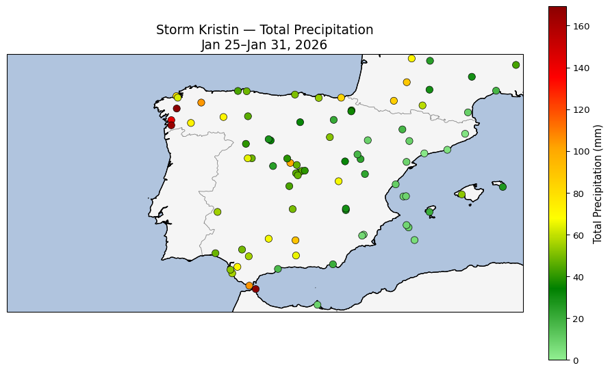

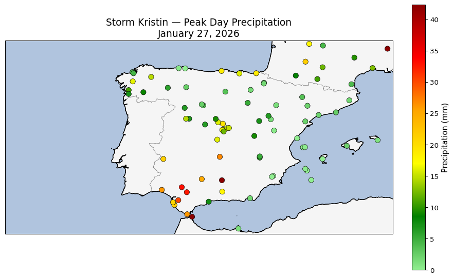

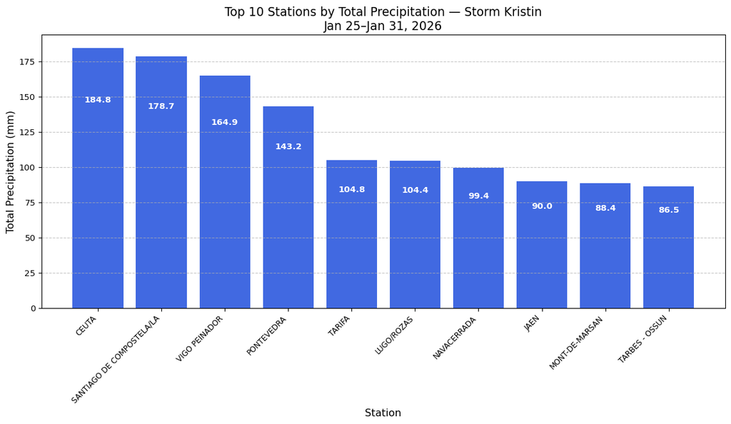

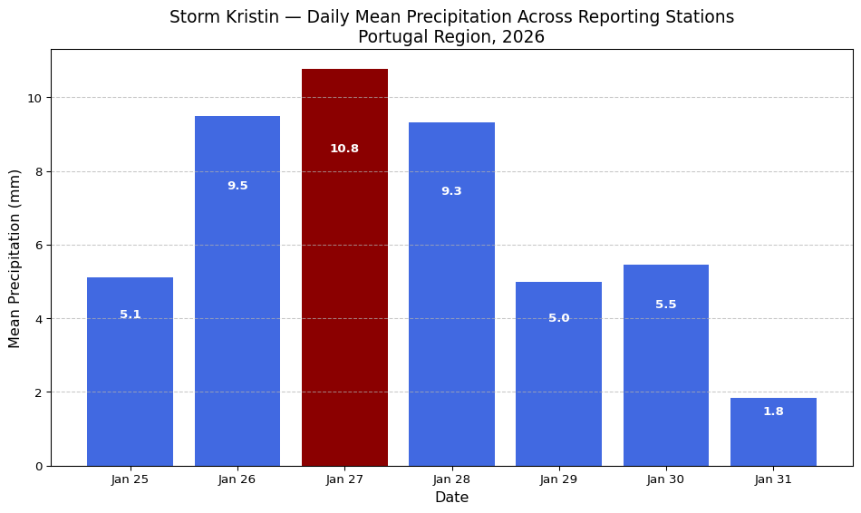